# PADP8120_Lab12: Matrices and Maximum Likelihood

Tyler Scott

2015-08-16

# Lab Topics

- Matrix-based regression
- Maximum likelihood estimators

## Goals:

After this lab you will be able to:

This lab uses materials by

- Andrew Bray
- Matthew Salganik
- Chris Adolph
- Trey Collier (http://www.exegetic.biz/blog/2013/08/fitting-a-model-by-maximum-likelihood/)

# Matrices in R

Let’s review matrix operations in R…

## Generating a matrix in R

```r
A <- matrix(c(2, -4, 5, 3, -1, -3), nrow = 2)
A
```

```
##      [,1] [,2] [,3]
## [1,]    2    5   -1
## [2,]   -4    3   -3
```

- The first argument is a vector of numbers.
- You also need to specify `nrow` or `ncol`.
- By default, `byrow = FALSE`, so it will spool the numbers down the columns first.
- Can also change a dataframe into a matrix directly with `as.matrix()`.
1. Produce the following as a matrix object:

1 | 7 | 10 |  
3 | 8 | 4 |  
5 | 9 | 4 |

## Matrix multiplication

```r
B <- matrix(c(2, 1, 0, 0, 1, 4), nrow = 3)
# A * B
C <- A %*% B
```

- The `*` operator will do element-wise multiplication.
- Use `%*%` for matrix multiplication (inner product).

## Other operations

*Transpose*: `t()`

```r
C
```

```
##      [,1] [,2]
## [1,]    9    1
## [2,]   -5   -9
```

```r
t(C)
```

```
##      [,1] [,2]
## [1,]    9   -5
## [2,]    1   -9
```

## Other operations

*Inverse*: `solve()`

```r
solve(C)
```

```
##             [,1]        [,2]
## [1,]  0.11842105  0.01315789
## [2,] -0.06578947 -0.11842105
```

```r
C %*% solve(C)
```

```
##               [,1] [,2]
## [1,]  1.000000e+00    0
## [2,] -1.110223e-16    1
```

$\begin{bmatrix} 3 & 1 \\ 2 & 1 \\ 1 & 0 \\ \end{bmatrix}$ $\begin{bmatrix} 1 & 0 & 2 \\ -1 & 3 & 1\\ \end{bmatrix}$

2. What size is the first matrix?
3. What size is the second matrix?
4. Can they multiplied together? If so, what will be the size of the result.
5. Calculate the result.

# Matrixes and linear regression

As we showed in lecture, a linear regression can be expressed a matrix algebra operation:

If our regression equation was…

$Y_i = \beta_0 + \beta_1 X_{i1} + \beta_2 X_{i2} + \beta_3 X_{i3} + \epsilon_i$

For 5 people this would be…

$y_1 = \beta_0 + \beta_1 x_{11} + \beta_2 x_{12} + \beta_3 x_{13} + \epsilon_1$

$y_2 = \beta_0 + \beta_1 x_{21} + \beta_2 x_{22} + \beta_3 x_{23} + \epsilon_2$

$y_3 = \beta_0 + \beta_1 x_{31} + \beta_2 x_{32} + \beta_3 x_{33} + \epsilon_3$

$y_4 = \beta_0 + \beta_1 x_{41} + \beta_2 x_{42} + \beta_3 x_{43} + \epsilon_4$

$y_5 = \beta_0 + \beta_1 x_{51} + \beta_2 x_{52} + \beta_3 x_{53} + \epsilon_5$

Which can then be repackaged as:

$\begin{bmatrix} y_1 \\ y_2 \\ y_3 \\ y_4 \\ y_5 \end{bmatrix}$ = $\begin{bmatrix} 1 & x_{11} & x_{12} & x_{13} \\ 1 & x_{21} & x_{22} & x_{23} \\ 1 & x_{31} & x_{32} & x_{33} \\ 1 & x_{41} & x_{42} & x_{43} \\ 1 & x_{51} & x_{52} & x_{53} \\ \end{bmatrix}$ $\begin{bmatrix} \beta_0 \\ \beta_1 \\ \beta_2 \\ \beta_3 \end{bmatrix}$ + $\begin{bmatrix} \epsilon_1 \\ \epsilon_2 \\ \epsilon_3 \\ \epsilon_4 \\ \epsilon_5 \end{bmatrix}$

$y_1 = \beta_0 + \beta_1 x_{11} + \beta_2 x_{12} + \beta_3 x_{13} + \epsilon_1$

$y_2 = \beta_0 + \beta_1 x_{21} + \beta_2 x_{22} + \beta_3 x_{23} + \epsilon_2$

$y_3 = \beta_0 + \beta_1 x_{31} + \beta_2 x_{32} + \beta_3 x_{33} + \epsilon_3$

$y_4 = \beta_0 + \beta_1 x_{41} + \beta_2 x_{42} + \beta_3 x_{43} + \epsilon_4$

$y_5 = \beta_0 + \beta_1 x_{51} + \beta_2 x_{52} + \beta_3 x_{53} + \epsilon_5$

## Goal of matrix regression

1. Our model is: $\mathbf{Y} = \mathbf{X} \mathbf{\beta} + \mathbf{\epsilon}$
2. We want to find $\mathbf{b}$ that minimizes the residual sum of squares
3. This is given by: $\mathbf{b} = \mathbf{(X'X)^{-1}X'y}$

## How does this work?

Let’s try it out. Load our old friend the `gapminder` package and fit a model that regresses life expetancy on GDP per capite (`lifeExp`~`gdpPercap`) **only** for the 2007 data:

```r
library(gapminder);library(dplyr)
gapdata <- gapminder %>% filter(year==2007)
gapmod = lm(lifeExp~gdpPercap,data=gapdata)
summary(gapmod)
```

```
##
## Call:
## lm(formula = lifeExp ~ gdpPercap, data = gapdata)
##
## Residuals:
##     Min      1Q  Median      3Q     Max
## -22.828  -6.316   1.922   6.898  13.128
##
## Coefficients:
##              Estimate Std. Error t value Pr(>|t|)
## (Intercept) 5.957e+01  1.010e+00   58.95   <2e-16 ***
## gdpPercap   6.371e-04  5.827e-05   10.93   <2e-16 ***
## ---
## Signif. codes:  0 '***' 0.001 '**' 0.01 '*' 0.05 '.' 0.1 ' ' 1
##
## Residual standard error: 8.899 on 140 degrees of freedom
## Multiple R-squared:  0.4606, Adjusted R-squared:  0.4567
## F-statistic: 119.5 on 1 and 140 DF,  p-value: < 2.2e-16
```

Now, we’ll find that same coefficient (6.371341410^{-4}) via the matrix approach…

The question ($\mathbf{b} = \mathbf{(X'X)^{-1}X'y}$) first shows that we need to take the transpose of X ($X'$). In this case, `X` (the design matrix) is simply a two-column matrix with a constant 1 (since we will fit the a constant intercept) and the value of `gdpPercap` for each country:

```r
X = cbind(1,gapdata$gdpPercap)
head(X)
```

```
##      [,1]       [,2]
## [1,]    1   974.5803
## [2,]    1  5937.0295
## [3,]    1  6223.3675
## [4,]    1  4797.2313
## [5,]    1 12779.3796
## [6,]    1 34435.3674
```

We then transpose X with the `t()` function:

```r
transX = t(X)
dim(transX)
```

```
## [1]   2 142
```

To take the inverse, we simply need to find the inverse of the product of `X` and `X'`. Note that this **does not** mean to simply set the product to the -1 power. Instead, we need the R function `solve` which will find the inverse of the matrix. Also, remember that for matrix multiplication in R, you have to use the `%*%` operator:

```r
solve(transX %*% X)
```

```
##               [,1]          [,2]
## [1,]  1.289277e-02 -5.008973e-07
## [2,] -5.008973e-07  4.288478e-11
```

… then multiply the resulting matrix by `X'` and `y`:

```r
solve(transX %*% X) %*% transX %*% gapdata$lifeExp
```

```
##              [,1]
## [1,] 5.956565e+01
## [2,] 6.371341e-04
```

Which should produce an identical set of coefficients as the original linear model:

```r
summary(gapmod)
```

```
##
## Call:
## lm(formula = lifeExp ~ gdpPercap, data = gapdata)
##
## Residuals:
##     Min      1Q  Median      3Q     Max
## -22.828  -6.316   1.922   6.898  13.128
##
## Coefficients:
##              Estimate Std. Error t value Pr(>|t|)
## (Intercept) 5.957e+01  1.010e+00   58.95   <2e-16 ***
## gdpPercap   6.371e-04  5.827e-05   10.93   <2e-16 ***
## ---
## Signif. codes:  0 '***' 0.001 '**' 0.01 '*' 0.05 '.' 0.1 ' ' 1
##
## Residual standard error: 8.899 on 140 degrees of freedom
## Multiple R-squared:  0.4606, Adjusted R-squared:  0.4567
## F-statistic: 119.5 on 1 and 140 DF,  p-value: < 2.2e-16
```

6. Load the Duncan’s occupational prestige dataset (`Duncan.txt`) and conduct a matrix-based regression for `income ~ education + presige`.

```r
prestige = read.table('input/Duncan.txt')
```

7. Compare your results to the `lm` output version.

# Maximum Likelihood Estimation

Step 1. Express the joint probability of the data, using the chosen probability distribution

Step 2. Convert the joint probability to the likelihood (trivial, as they are proportional)

Step 3. Simplify the likelihood for easy maximization (take logs and reduce to “sufficient statistics”)

Step 4. Substitute in the systematic component

Now we have something easy to maximize, and will be able to estimate the parameters given the data

## MLE Example

Here is some fake, normally distributed data:

```r
x <- c(85,84,75,93,88,82,85,94,86,76,81,98,95,82,76,91,81,82,72,94)
```

Assume that you want to model these data as coming from a gaussian random process. That is, there is some unknown mean $\mu$ and variance $\sigma^2$ Thus our model has two unknown parameters.

Obviously, there is a really easy way to solve these:

$\mu = \frac{1}{N}\sum^{N}_{i=1} x_i$

and…

$\hat{\sigma} = \frac{1}{N} \sum^{N}_{i=1} (x_i - \hat{\mu})^2$

… but let’s pretend like there is not!

## What’s the point?

The point of MLE is to show that as long as you have a forward model of the probability of the data given a guess at the parameter(s), you can use an optimizer to find the parameter value(s) that maximize the likelihood (minimize the negative log-likelihood, which you might recall showing up in `summary.lm` objects) of the data given the parameter(s).

The following function computes the NLL of the data $x$ given our guesses of $\mu$ and $\sigma^2$:

```r
NLL <- function(theta,data) {
mu = theta[1]
sigma = theta[2]
n = length(data)
NLL = -(n/2)*log(2*pi) - (n/2)*log(sigma**2)
tmp = 0
for (i in 1:n) {
tmp = tmp + (data[i]-mu)**2
}
NLL = NLL + -(1/(2*(sigma**2)))*tmp
 -NLL
}
```

You can refer to the lecture notes to see the Greek equation version of this function. R has a built-in optimizer function that will take: (a) a vector of parameters guesses we feed in; and (b) the `NLL` function we just built; and (c) the data:

```r
test.vector = c(100,10) #guess values for mu and sigma^2
outp = optim(par = test.vector,fn = NLL, data = x)
outp$par
```

```
## [1] 84.998857  7.183545
```

What comes out is the best parameter estimates. You have to feed in starting values, but then the `optim` function takes it from there and gives you the optimal parameter estimates.

8. Repeat the operation above but start with a different set of guesses. Do you get the same result?
9. What about some really bad guesses (e.g., `c(10000,300)`)? Does `optim` still get there?

## MLE and Regression

As you have seen, MLE bascially inverts the question we have been asking all semester, now saying: what model parameters are most likely to characterise a given set of data? Now let’s try something a little more sophisticated: fitting a linear model. As before, we generate some data.

```r
set.seed(24)
N <- 100
x <- runif(N)
y <- 5 * x + 3 + rnorm(N)
```

We can immediately fit this model using least squares regression.

```r
fit <- lm(y ~ x)
summary(fit)
```

```
##
## Call:
## lm(formula = y ~ x)
##
## Residuals:
##     Min      1Q  Median      3Q     Max
## -2.3971 -0.6742  0.1002  0.5903  2.8253
##
## Coefficients:
##             Estimate Std. Error t value Pr(>|t|)
## (Intercept)   2.8593     0.1901   15.04   <2e-16 ***
## x             5.1173     0.3570   14.34   <2e-16 ***
## ---
## Signif. codes:  0 '***' 0.001 '**' 0.01 '*' 0.05 '.' 0.1 ' ' 1
##
## Residual standard error: 0.9705 on 98 degrees of freedom
## Multiple R-squared:  0.6771, Adjusted R-squared:  0.6738
## F-statistic: 205.5 on 1 and 98 DF,  p-value: < 2.2e-16
```

But that’s not all that fun.

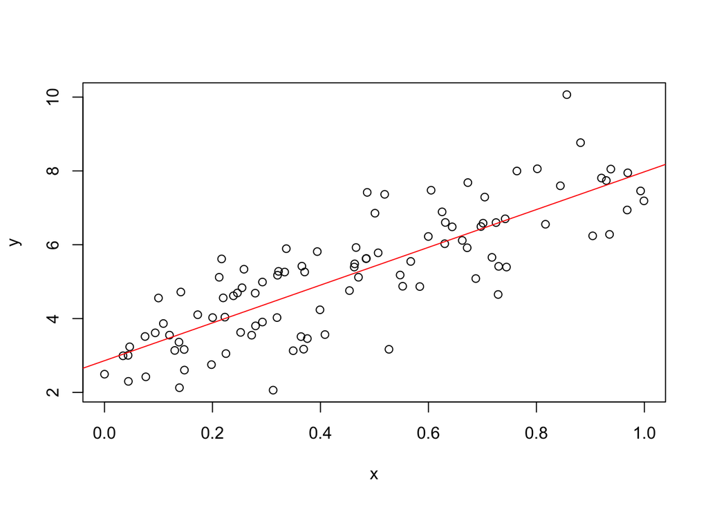

```r
plot(x, y)
abline(fit, col = "red")
```

## Likelihood function for linear regression

As before, we need a likelihood function. The model is not a PDF (probability density function), so we can’t proceed in precisely the same way that we did with the normal distribution. However, if you fit a linear model then you want the residuals to be normally distributed. So the likelihood function fits a normal distribution to the residuals.

```r
regLL <- function(params, data) {
    # Find residuals
    #
    R = data$y - data$x * params[['beta1']] - params[['beta0']]
    #
    # Calculate the likelihood for the residuals (with mu and sigma as parameters)
    #
    R = suppressWarnings(dnorm(R, params[['mu']], params[['sigma']]))
    #
    # Sum the log likelihoods for all of the data points
    #
    -sum(log(R))
}
```

Next we fit the model.

```r
start.values = list(beta0 = 3, beta1 = 1, mu = 0, sigma=1)
mle.estimate = optim(par = start.values,fn = regLL,data = data.frame(cbind(x,y)))
mle.estimate
```

```
## $par
##     beta0     beta1        mu     sigma
## 2.3220018 5.1167993 0.5375155 0.9606568
##
## $value
## [1] 137.8852
##
## $counts
## function gradient
##      183       NA
##
## $convergence
## [1] 0
##
## $message
## NULL
```

How does this compare to the `lm` result?

```r
ols.estimate = lm(y~x)
summary(ols.estimate)
```

```
##
## Call:
## lm(formula = y ~ x)
##
## Residuals:
##     Min      1Q  Median      3Q     Max
## -2.3971 -0.6742  0.1002  0.5903  2.8253
##
## Coefficients:
##             Estimate Std. Error t value Pr(>|t|)
## (Intercept)   2.8593     0.1901   15.04   <2e-16 ***
## x             5.1173     0.3570   14.34   <2e-16 ***
## ---
## Signif. codes:  0 '***' 0.001 '**' 0.01 '*' 0.05 '.' 0.1 ' ' 1
##
## Residual standard error: 0.9705 on 98 degrees of freedom
## Multiple R-squared:  0.6771, Adjusted R-squared:  0.6738
## F-statistic: 205.5 on 1 and 98 DF,  p-value: < 2.2e-16
```

Looks like we did good!

## Another synthetic example

How smooth should our model be?

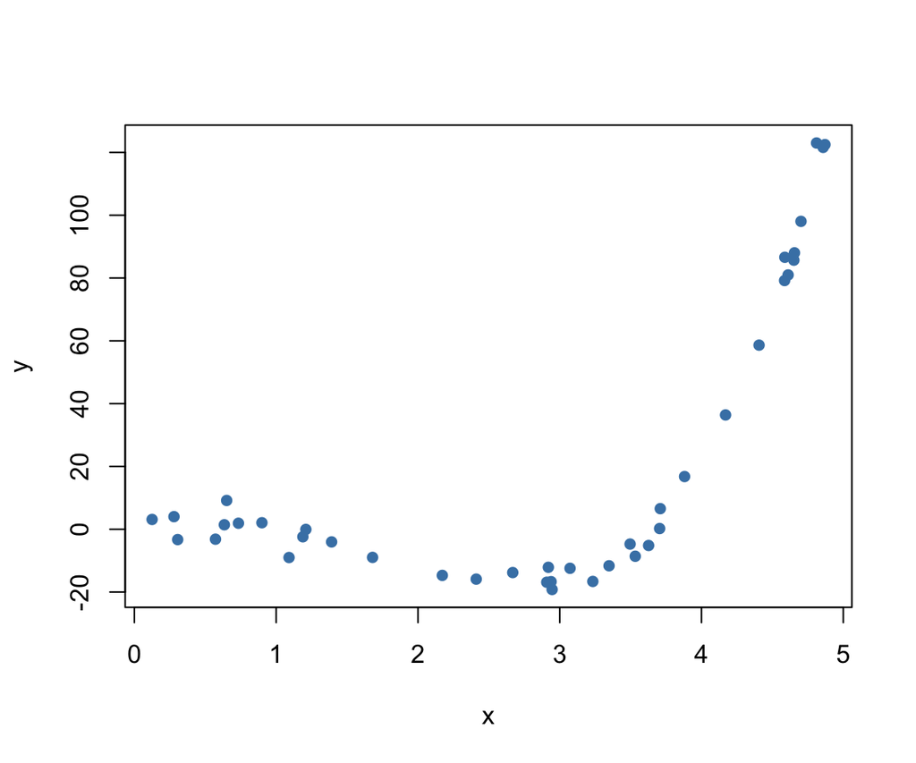

```r
betas <- c(0, 1, 1, -4, 1)
sigma <- 5
n <- 40
set.seed(110)
x <- runif(n, 0, 5)
EyGx <- betas[1] + betas[2]*x + betas[3]*x^2 + betas[4]*x^3 + betas[5]*x^4
y <- EyGx + rnorm(n, 0, sigma)
plot(y ~ x, pch = 16, col = "steelblue")
```

## Four candidates

```r
m1 <- lm(y ~ x)
m2 <- lm(y ~ x + I(x^2))
m3 <- lm(y ~ x + I(x^2) + I(x^3))
m4 <- lm(y ~ x + I(x^2) + I(x^3) + I(x^4))
```

## Four candidates

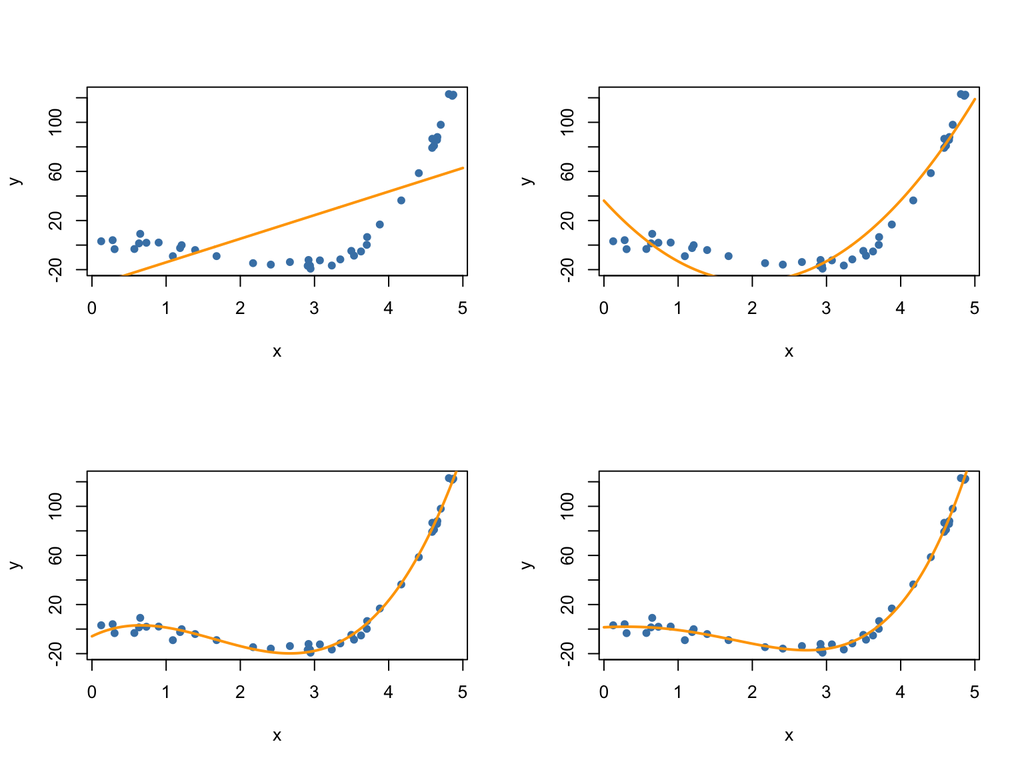

## Likelihood

**Def:** the joint probability (actually: density) of all of the data given a particular model. If our $Y$s are independent of each other given the $X$, then:

$P(Y_. | X_.) = P(y_1 | x_1) P(y_2 | x_2) \ldots P(y_n | x_n)$

```r
L1 <- prod(dnorm(m1$res, mean = 0, sd = summary(m1)$sigma))
```

## Comparing Likelihoods

```r
L1 <- prod(dnorm(m1$res, mean = 0, sd = summary(m1)$sigma))
L2 <- prod(dnorm(m2$res, mean = 0, sd = summary(m2)$sigma))
L3 <- prod(dnorm(m3$res, mean = 0, sd = summary(m3)$sigma))
L4 <- prod(dnorm(m4$res, mean = 0, sd = summary(m4)$sigma))
c(L1, L2, L3, L4)
```

```
## [1] 1.845701e-86 1.252416e-69 2.682451e-49 6.055980e-47
```

The observed data is most probable under the model with a quartic term. So that’s the best model, right?

## The BEST model!

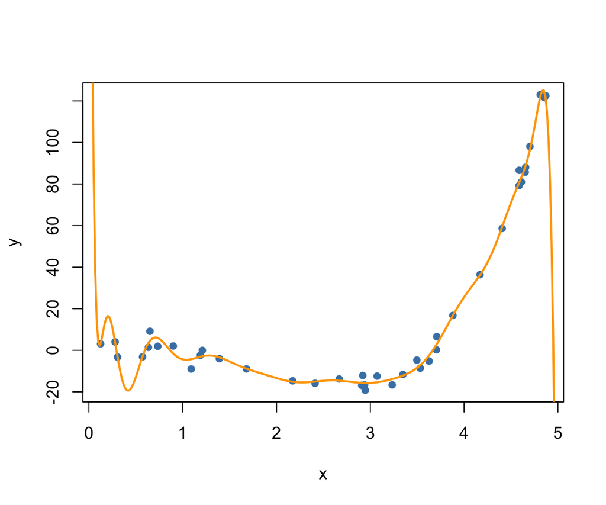

## The BEST model!

```r
mBEST <- lm(y ~ poly(x, 20))
LBEST <- prod(dnorm(mBEST$res, mean = 0, sd = summary(mBEST)$sigma))
c(L1, L2, L3, L4, LBEST)
```

```
## [1] 1.845701e-86 1.252416e-69 2.682451e-49 6.055980e-47 1.052673e-42
```

But surely that’s not the best model…

## Criteria compared

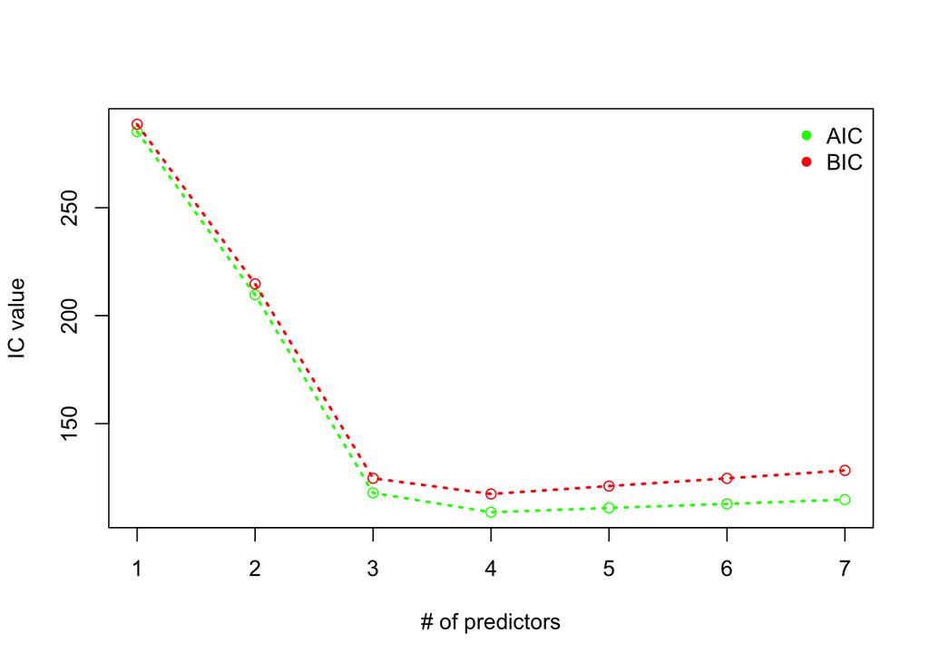